# Part II - Citi Bike Data Exploration

## by Abdalhameed Saad

## Investigation Overview

> The overall goals for the presentation is to show the following
> - highlight the age range that has the most trips
> - frequencies of rider gender and user type and the trip duration
> - trip frequencies by weekday and usertype.
> - user type distributions based on user gender and trip duration, as well as user type distributions based on user weekday and trip duration
> - month that has the most trips
> - the effect of weekday on the number of trips

## Dataset Overview

> Citi Bike is New York City’s bike share system, and the largest in the nation. Citi Bike launched in May 2013 and has become an essential part of transportation network. They make commute fun, efficient and affordable – not to mention healthy and good for the environment.

> Where do Citi Bikers ride? When do they ride? How far do they go? Which stations are most popular? What days of the week are most rides taken on? Discovering the answers to these questions and more.

### Which age range has the most trips?

> users between the age of 30 to 35 has more trips than other age in the disruption,I only need to adjust the bin in the subplot.

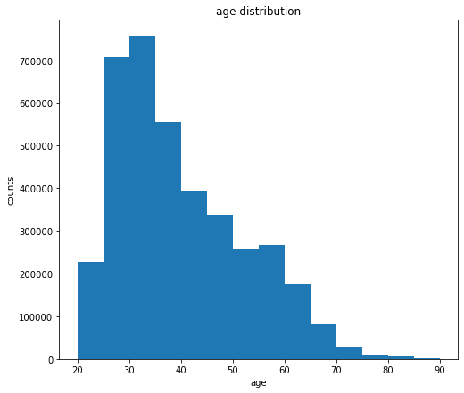

### does user type and gender have correlation with the duration time take for each trip?

> It is evident that female customers had longer trips compared to male customers in the last plot, which shows there are clear differences between them.

> customers tend to have more trip duration than subscriber

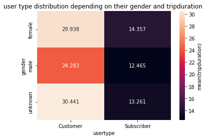

### does trip frequencies by weekday and usertype effect the trip duration?

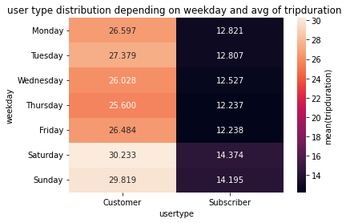

### Which month has the most trips?

> month of January has the most trips

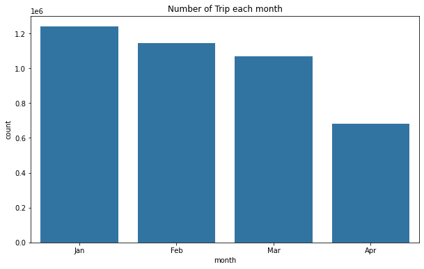

## does weekday effect the number of trips ?

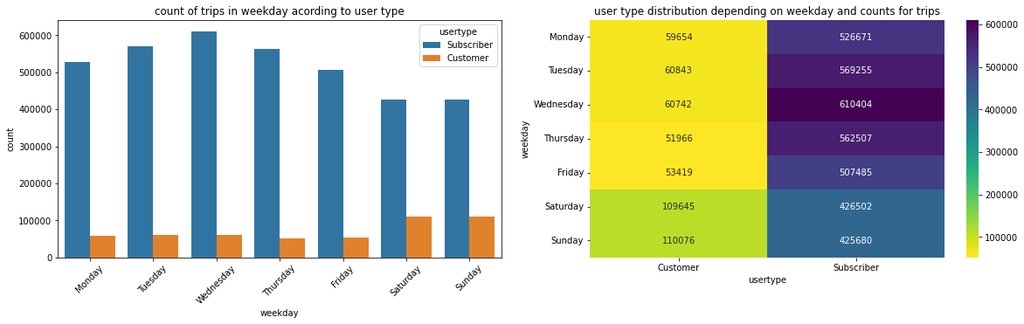